# Project 3 - Statistics and Visualization

Ji-Eun Park

## Background

**Urban Ministries of Durham (UMD)** is a non-profit organization offering food, shelter and other services necessary for people in need of those aids. This project is designed to bring meaningful insights from the supply data gathered since around 1990’s which is almost since the foundation of this organization (1983).

## Project Goal

The aim of this project is to provide UMD with useful and invaluable information about the organization and the clients and provide analytic information and suggest insightful ideas for UMD.

## Data

UMD has provided 16 datasets including such as client/provider information, disability at entry/exit, health insurance at entry/exit, income at entry/exit, noncash support received entry/exit, etc.

## Analysis Results

### 1. Demographics of UMD clients

#### ii) Age Groups

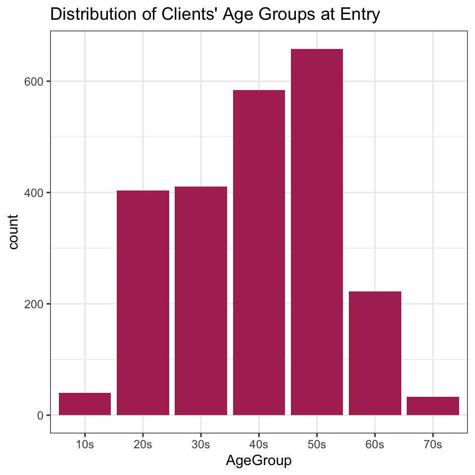

Results show that majority of the clients are in their 20s to 50s, where 40-50s have the highest proportion.

#### iii) Gender

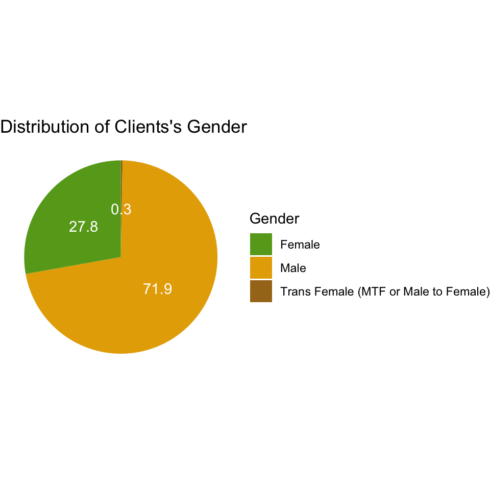

You can see that the clients at UMD have 72% male clients and 28% female clients. Very minor, but there also exists some MTF clients.

#### iv) Veteran Status

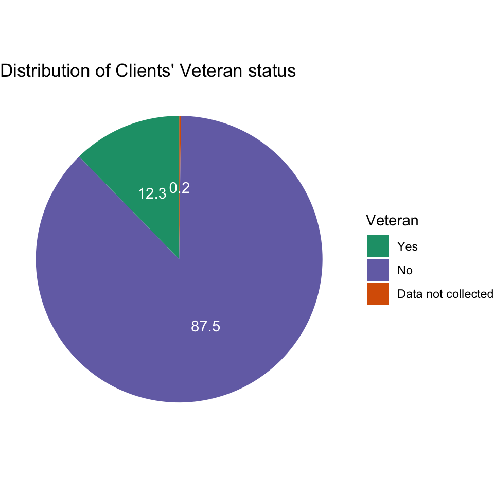

12.3% of the clients are veterans.

### 2. How did the income and non-cash support change from entry to exit? Were there any improvements?

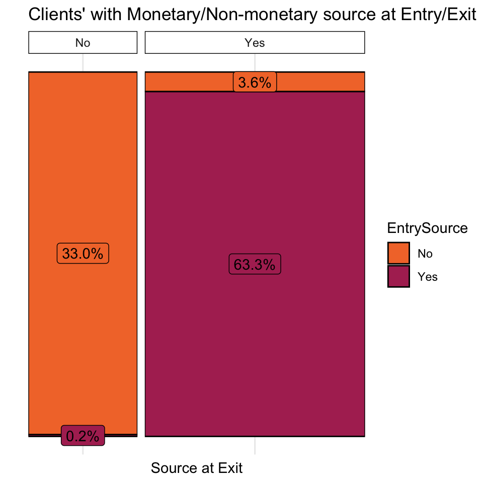

The above plot summarizes the ratio of clients who had monetary or non-monetary source of support at entry versus exit of the program. As we can observe, around 96% of the clients did not have change in the status, either did not have any source at entry and exit, or had a source at entry and exit.

Only 3.6% of the clients who did not have source at entry found a source at exit. And although it is minor, 0.2% of the clients lost their existing source at exit.

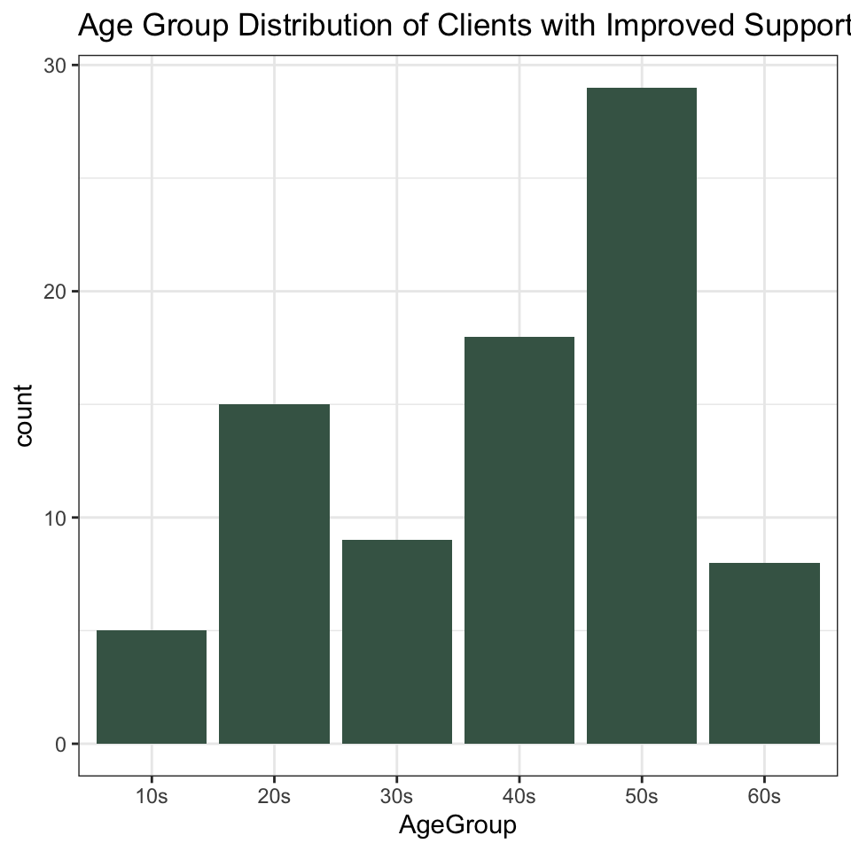

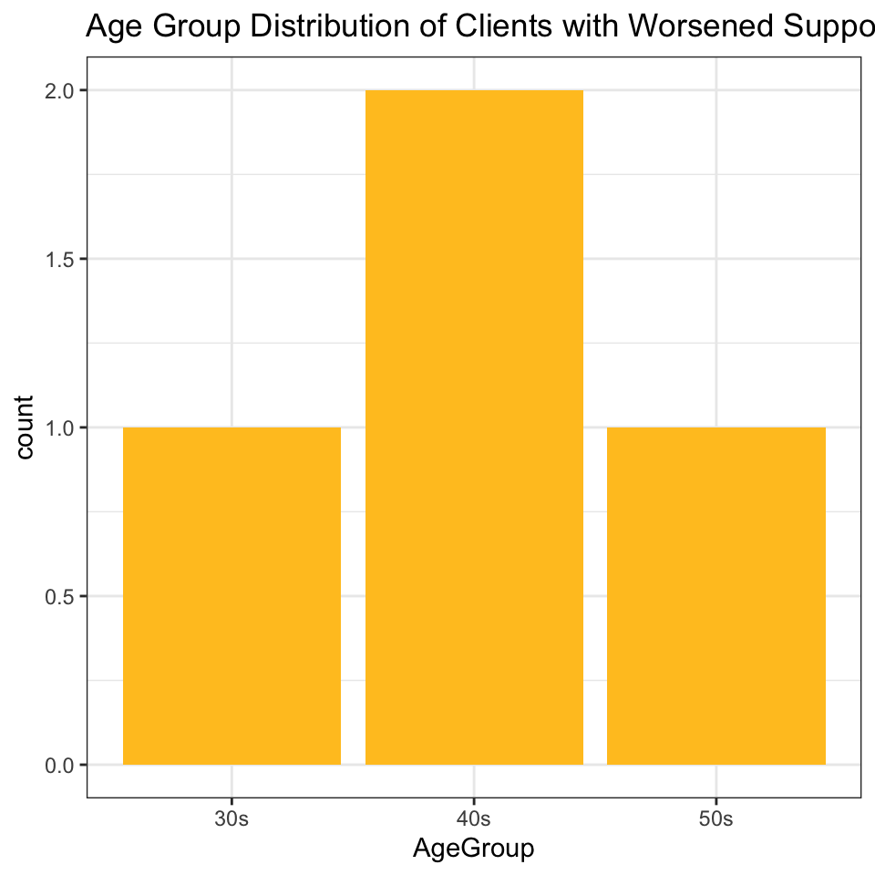

### 3. What are the major reasons why the clients left?

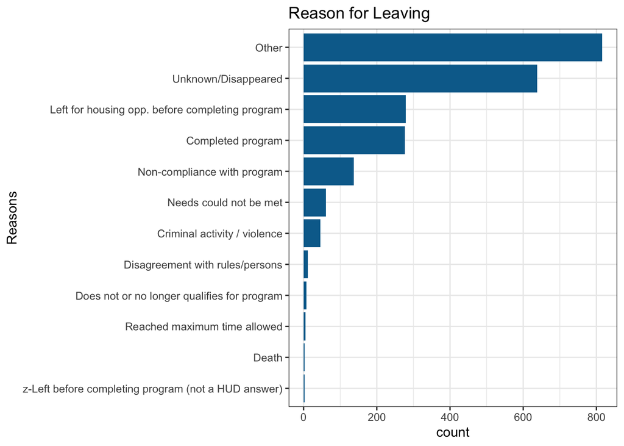

Also, many clients left due to completion of program or housing opportunities, around 200 clients (out of 2352) had to leave due to non-compliance or due to needs not met. This is also something UMD might want to look into, in order to provide more service and goods to variety of people.

Let’s look deeper on who left for each reason.

Age distribution in clients reason for leaving is unknown/disappeared

| AgeGroup | count | totalcount | percentage |
| --- | --- | --- | --- |
| 10s | 11 | 40 | 0.275 |
| 20s | 123 | 404 | 0.304 |
| 30s | 129 | 411 | 0.314 |
| 40s | 151 | 584 | 0.259 |
| 50s | 176 | 658 | 0.267 |
| 60s | 43 | 222 | 0.194 |
| 70s | 5 | 33 | 0.152 |

Age distribution in unsatisfied clients

| AgeGroup | count | totalcount | percentage |
| --- | --- | --- | --- |
| 10s | 1 | 40 | 0.025 |
| 20s | 14 | 404 | 0.035 |
| 30s | 13 | 411 | 0.032 |
| 40s | 11 | 584 | 0.019 |
| 50s | 12 | 658 | 0.018 |
| 60s | 8 | 222 | 0.036 |
| 70s | 2 | 33 | 0.061 |

Age distribution in clients complete program

| AgeGroup | count | totalcount | percentage |
| --- | --- | --- | --- |
| 10s | 3 | 40 | 0.075 |
| 20s | 30 | 404 | 0.074 |
| 30s | 28 | 411 | 0.068 |
| 40s | 72 | 584 | 0.123 |
| 50s | 93 | 658 | 0.141 |
| 60s | 38 | 222 | 0.171 |
| 70s | 13 | 33 | 0.394 |

One noticeable characteristics of patients for the major reasons for leaving is that clients from 20s and 30s were more likely to disappear or leave without giving reason compared to 40s to 60s who were more likely to stay until completion of the program.

This may indicate that the UMD service is focused on elders but not youngs.

### 4. Relationship between length of stay and client demographics

#### i) Race

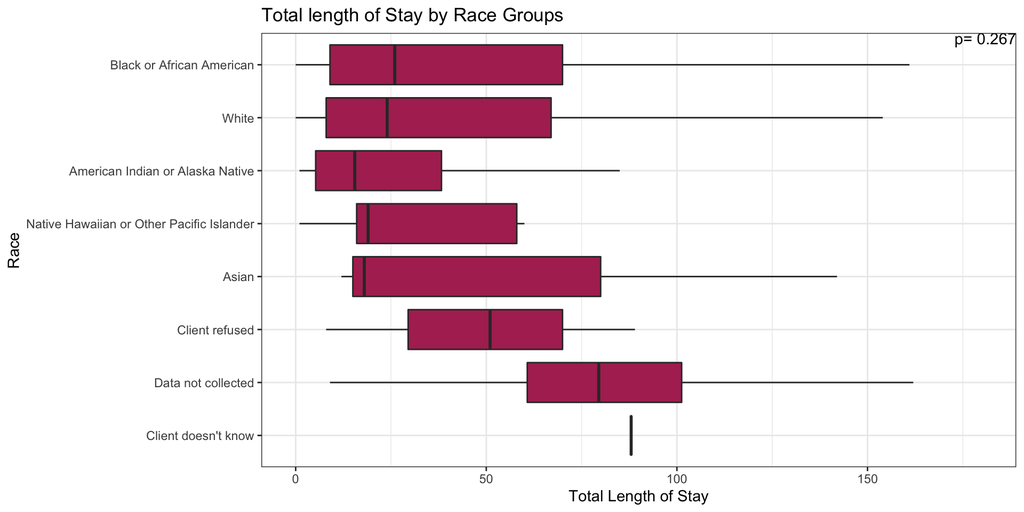

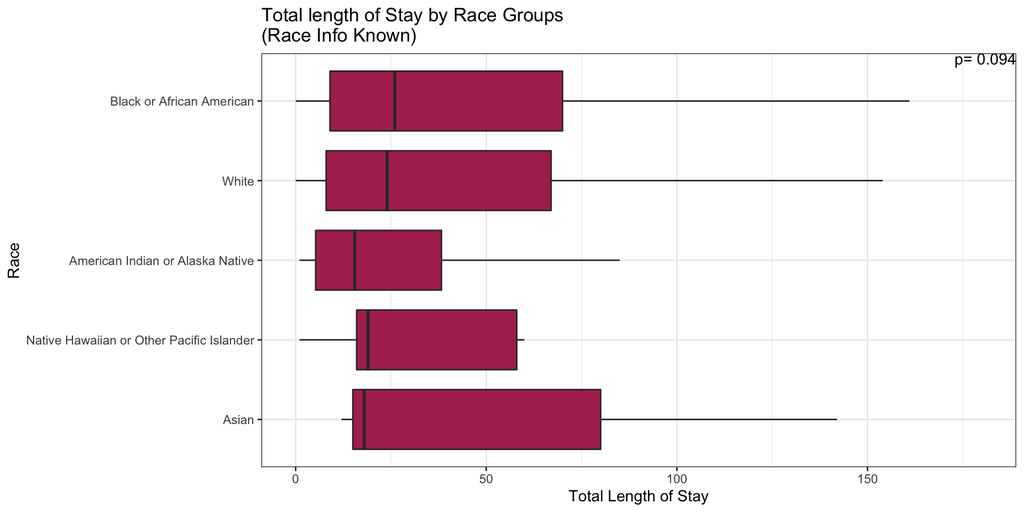

Above are the boxplots which shows the distribution of the total length of stay clients in each Race group. The first one is based on the entire dataset, while the second one is only based on data with Race group known. I used the Kruskal Wallis test, which is a non-parametric multigroup comparison test to see if there’s significant difference in the total length of stay among race groups. However, both results does not show significant difference (p=0.267, 0.094) under the significance level 0.05.

#### ii) Age Group

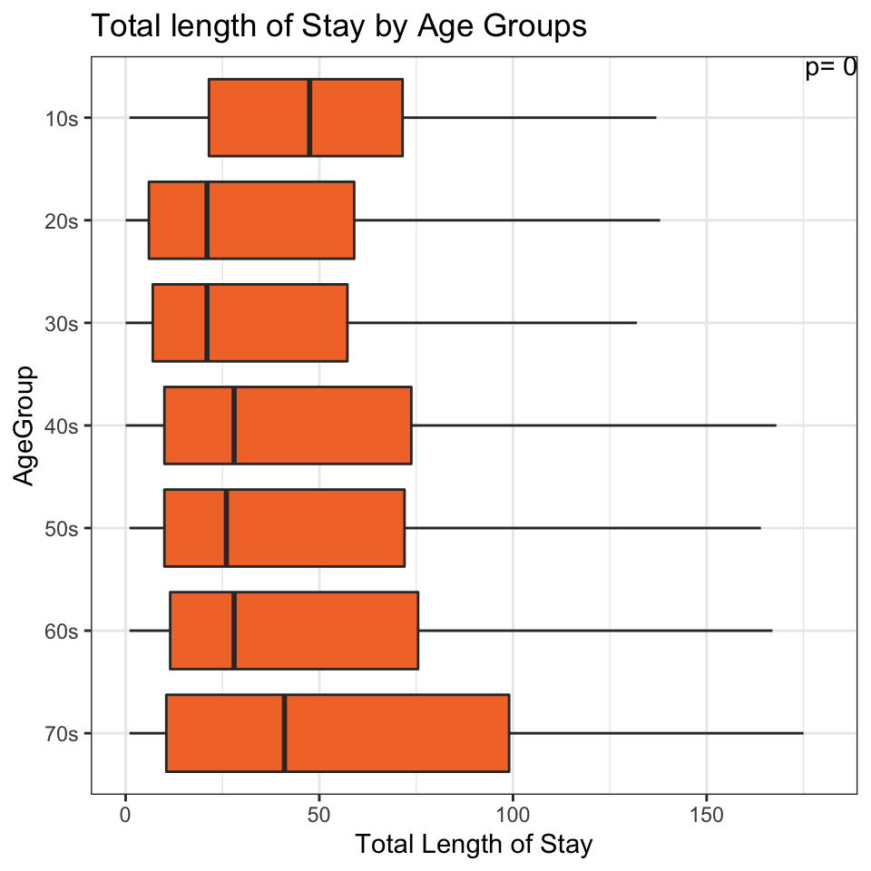

Above are the boxplots which shows the distribution of the total length of stay clients in each Age group. Our Kruskal-Wallis test showed significant difference in total length of stay between some Age groups. Based on pairwise wilcoxon test we know that the following groups have significant difference: 40s vs 20s,50s vs 20s,60s vs 20s,70s vs 20s,40s vs 30s,50s vs 30s,60s vs 30s,70s vs 30s.

Hence, we can see that clients in their 20s, 30s tend to have a significantly lower total length of stay.

#### iii) Gender

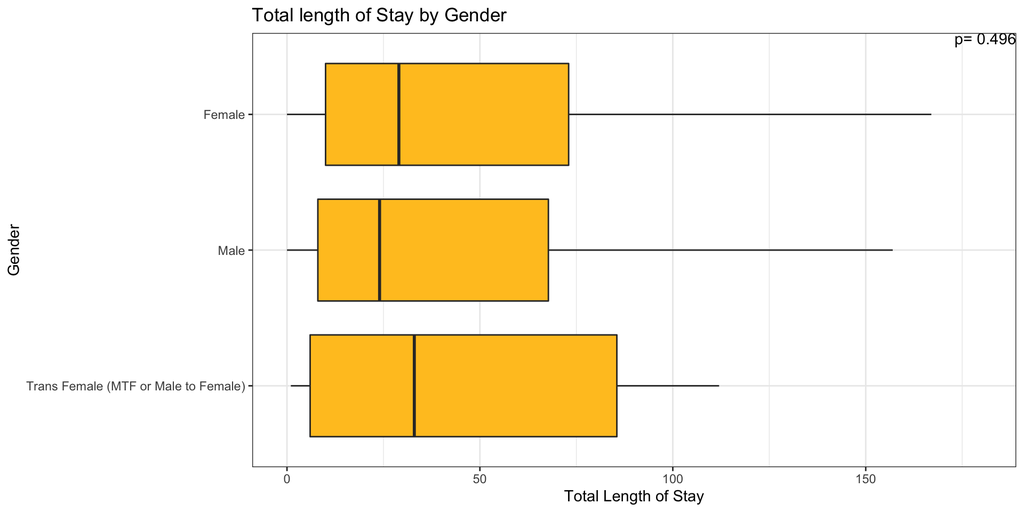

Same process was done on Gender groups, but there were no significant difference between Gender groups.

#### iv) Veteran status

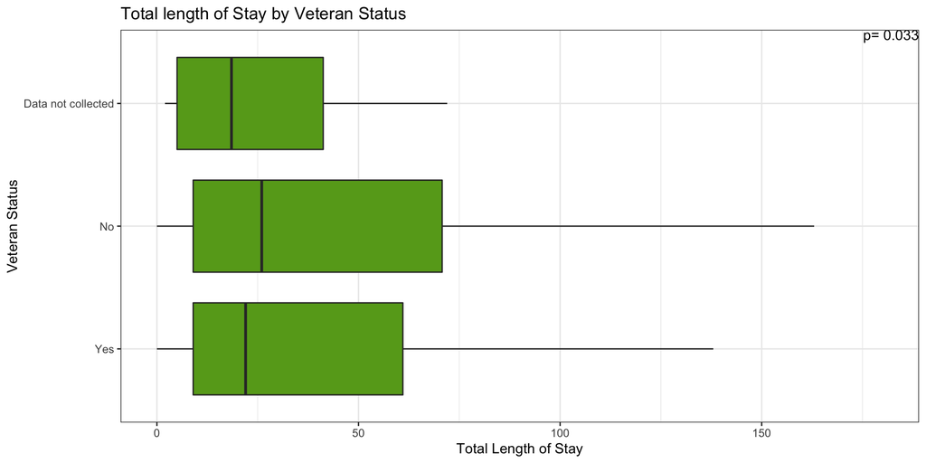

### 5. Relationship between client recurrence and demographics

Same process as question 4. Although we are using non-parametric methods to test significance different groups, since the values are very small, barplots will be used instead of boxplots.

#### i) Race

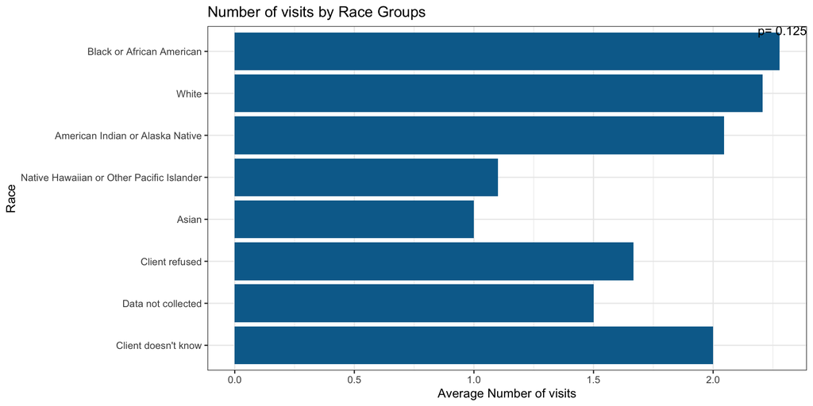

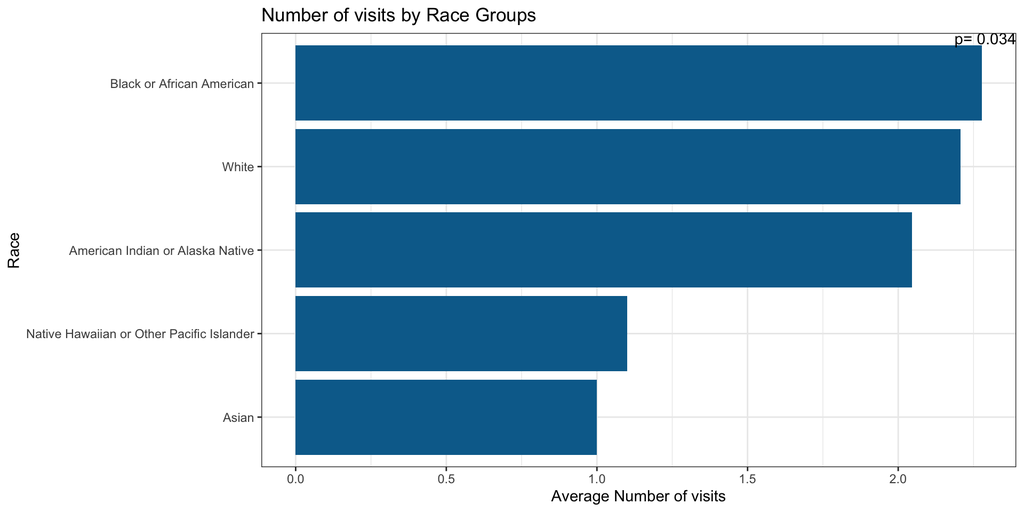

Same process was done with number of visits instead of total length of stay. Results show that when data with unkown race were removed, there are significant differences between some Race groups. Based on wilcoxon rank sum test, Native Hawaiian/Other Pacific Islander vs Black/African American,Native Hawaiian/Other Pacific Islander vs White have significant difference. Hence we can see Native Hawaiian or Other Pacific Islanders have significantly less recurrence compared to White or Black/African American clients.

#### ii) Age Group

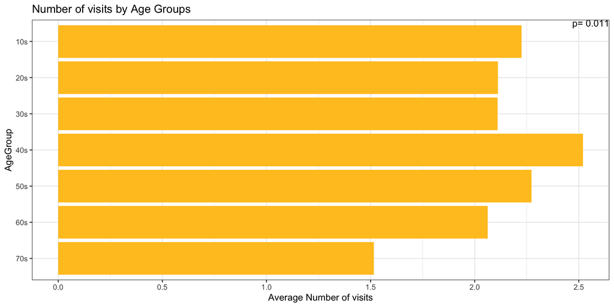

Kruskal-Wallis test showed significant difference in number of visits between some Age groups. Based on pairwise wilcoxon test we know that the following groups have significant difference: 70s vs 10s,60s vs 40s,70s vs 40s,60s vs 50s,70s vs 50s.

Hence, we can see that clients in their 60s and 70s tend to have a significantly lower recurrence.

#### iii) Gender

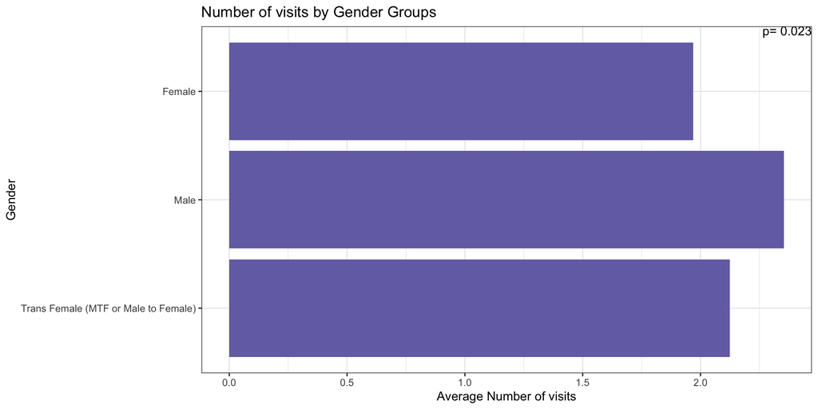

#### iv) Veteran status

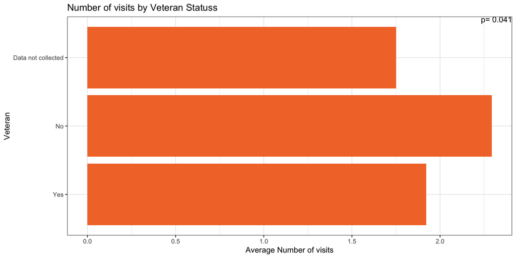

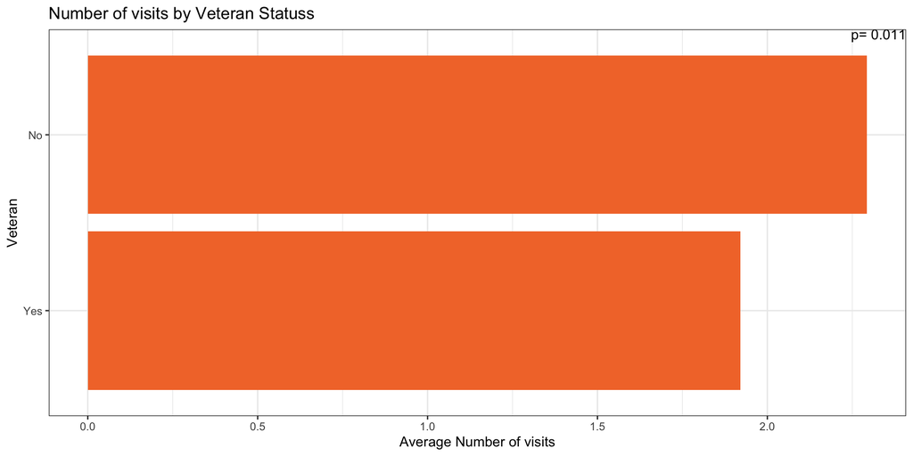

For Veteran status, the difference was checked for both 1)whole data, and 2)data without clients with unkown veteran status. Since we only have two veteran status (veteran vs not veteran), it is implied from the boxplot that veterans have lower recurrence than non veterans.